# Pertemuan 3 - Regresi dengan Peubah Lag

## DATASET

```r
dt <- rio::import("C:/Users/daffa/Downloads/NewDelhi_Air_quality.csv")
str(dt)
```

```
## 'data.frame':    72 obs. of  12 variables:
##  $ V1             : int  0 1 2 3 4 5 6 7 8 9 ...
##  $ AQI            : num  30.2 28.2 26.6 25 26 26 26 24 23 24 ...
##  $ CO             : num  199 198 199 202 205 ...
##  $ datetime       : chr  "2022-10-21:18" "2022-10-21:19" "2022-10-21:20" "2022-10-21:21" ...
##  $ no2            : num  0.0469 0.0465 0.0469 0.0482 0.0489 ...
##  $ o3             : num  55.8 54.9 54.6 55.1 55.8 ...
##  $ pm10           : num  10.5 10.7 11.2 11.1 10.4 ...
##  $ pm25           : num  5.64 4.62 3.52 2.23 1.98 ...
##  $ so2            : num  0.387 0.41 0.402 0.376 0.339 ...
##  $ timestamp_local: POSIXct, format: "2022-10-21 23:00:00" "2022-10-22 00:00:00" ...
##  $ timestamp_utc  : POSIXct, format: "2022-10-21 18:00:00" "2022-10-21 19:00:00" ...
##  $ ts             : int  1666375200 1666378800 1666382400 1666386000 1666389600 1666393200 1666396800 1666400400 1666404000 1666407600 ...
```

```r
dt
```

```
##    V1  AQI       CO      datetime        no2       o3      pm10     pm25
## 1   0 30.2 198.6027 2022-10-21:18 0.04685717 55.78995 10.486722 5.637410
## 2   1 28.2 197.6013 2022-10-21:19 0.04645554 54.93164 10.719325 4.618169
## 3   2 26.6 198.6027 2022-10-21:20 0.04685717 54.64554 11.155578 3.520902
## 4   3 25.0 201.9405 2022-10-21:21 0.04819594 55.07469 11.116206 2.225919
## 5   4 26.0 205.2784 2022-10-21:22 0.04886533 55.78995 10.405250 1.979471
## 6   5 26.0 208.6163 2022-10-21:23 0.05020411 56.50520  9.402518 1.792677
## 7   6 26.0 208.6163 2022-10-22:00 0.05020411 55.78995  8.482822 1.752237
## 8   7 24.0 205.2784 2022-10-22:01 0.05020411 52.92892  7.586667 1.858459
## 9   8 23.0 200.2716 2022-10-22:02 0.04685717 50.06790  7.636587 2.208076
## 10  9 24.0 196.9338 2022-10-22:03 0.04417961 51.49841  8.487648 2.476681
## 11 10 25.0 198.6027 2022-10-22:04 0.04284084 53.64418  9.357371 2.585729
## 12 11 26.0 200.2716 2022-10-22:05 0.04049798 55.78995 10.338728 2.390081
## 13 12 27.0 203.6095 2022-10-22:06 0.04016329 59.36623 10.523314 2.086022
## 14 13 29.0 205.2784 2022-10-22:07 0.03882451 62.22725 10.635970 1.937047
```

[output cut: 131 more lines]

```r
data <- data.frame(
  t   = dt$V1 + 1,
  Yt   = dt$AQI,
  Yt1 = dplyr::lag(dt$AQI, 1),
  Xt  = dt$no2
)
data
```

```
##     t   Yt  Yt1         Xt
## 1   1 30.2   NA 0.04685717
## 2   2 28.2 30.2 0.04645554
## 3   3 26.6 28.2 0.04685717
## 4   4 25.0 26.6 0.04819594
## 5   5 26.0 25.0 0.04886533
## 6   6 26.0 26.0 0.05020411
## 7   7 26.0 26.0 0.05020411
## 8   8 24.0 26.0 0.05020411
## 9   9 23.0 24.0 0.04685717
## 10 10 24.0 23.0 0.04417961
## 11 11 25.0 24.0 0.04284084
## 12 12 26.0 25.0 0.04049798
## 13 13 27.0 26.0 0.04016329
## 14 14 29.0 27.0 0.03882451
```

[output cut: 58 more lines]

## SPLIT DATA

Kita bagi data train 80% dan data test 20%

```r
train<-data[1:57,]
test<-data[58:72,]
```

Setelah itu ubah jadi data time series

```r
train.ts<-ts(train)
test.ts<-ts(test)
data.ts<-ts(data)
```

## Model Koyck

### Pemodelan

```r
model.koyck <- koyckDlm(x = train$Xt, y = train$Yt)
summary(model.koyck)
```

```
##
## Call:
## "Y ~ (Intercept) + Y.1 + X.t"
##
## Residuals:
##      Min       1Q   Median       3Q      Max
## -2.22117 -0.48388 -0.04424  0.56575  2.23616
##
## Coefficients:
##             Estimate Std. Error t value Pr(>|t|)
## (Intercept)  2.46731    1.55225   1.590    0.118
## Y.1          0.85980    0.06108  14.076   <2e-16 ***
## X.t         27.86813   17.31971   1.609    0.114
## ---
## Signif. codes:  0 '***' 0.001 '**' 0.01 '*' 0.05 '.' 0.1 ' ' 1
##
## Residual standard error: 0.9049 on 53 degrees of freedom
## Multiple R-Squared: 0.8279,  Adjusted R-squared: 0.8215
## Wald test: 127.3 on 2 and 53 DF,  p-value: < 2.2e-16
##
## Diagnostic tests:
## NULL
##
##                             alpha     beta       phi
## Geometric coefficients:  17.59833 27.86813 0.8597988
```

Sekarang cek AIC dan BIC

```r
AIC(model.koyck)
```

```
## [1] 152.641
```

```r
BIC(model.koyck)
```

```
## [1] 160.7424
```

### Peramalan dan Akurasi

```r
fore.koyck <- forecast(model = model.koyck, x=test$Xt, h=15)
fore.koyck
```

```
## $forecasts
##  [1] 24.99761 24.72506 24.31817 23.86572 23.42541 23.04217 22.78261 22.67137
##  [9] 22.67833 22.81489 23.07222 23.39606 23.81442 24.24874 24.64082
##
## $call
## forecast.koyckDlm(model = model.koyck, x = test$Xt, h = 15)
##
## attr(,"class")
## [1] "forecast.koyckDlm" "dLagM"
```

```r
mape.koyck <- MAPE(fore.koyck$forecasts, test$Yt)
mape.koyck
```

```
## [1] 0.1181713
```

```r
GoF(model.koyck)
```

```
##              n       MAE          MPE       MAPE      sMAPE     MASE       MSE
## model.koyck 56 0.6820742 -0.001034498 0.02522531 0.02517156 1.065741 0.7749148
##                   MRAE    GMRAE
## model.koyck 1103570317 14261.57
```

Didapat nilai MAPE dari data test sebesar 0.1181713

## Regression with Distributed Lag

```r
model.dlm <- dlm(x = train$Xt,y = train$Yt , q = 1)
summary(model.dlm)
```

```
##
## Call:
## lm(formula = model.formula, data = design)
##
## Residuals:
##     Min      1Q  Median      3Q     Max
## -4.7894 -1.1771 -0.2437  0.9569  4.0981
##
## Coefficients:
##             Estimate Std. Error t value Pr(>|t|)
## (Intercept)   21.879      1.483  14.752   <2e-16 ***
## x.t          -16.307     80.569  -0.202    0.840
## x.1          132.953     80.542   1.651    0.105
## ---
## Signif. codes:  0 '***' 0.001 '**' 0.01 '*' 0.05 '.' 0.1 ' ' 1
##
## Residual standard error: 1.941 on 53 degrees of freedom
## Multiple R-squared:  0.2085, Adjusted R-squared:  0.1786
## F-statistic: 6.979 on 2 and 53 DF,  p-value: 0.00204
##
## AIC and BIC values for the model:
##        AIC      BIC
## 1 238.1067 246.2081
```

```r
AIC(model.dlm)
```

```
## [1] 238.1067
```

```r
BIC(model.dlm)
```

```
## [1] 246.2081
```

### Peramalan dan Akurasi

Berikut merupakan hasil peramalan untuk 15 periode kedepan

```r
fore.dlm <- forecast(model = model.dlm, x=test$Xt, h=15)
fore.dlm
```

```
## $forecasts
##  [1] 27.32471 26.37053 25.18104 24.41786 23.95839 23.71638 23.65320 23.92144
##  [9] 24.39539 24.80846 25.34957 25.95701 26.36462 26.98844 27.33351
##
## $call
## forecast.dlm(model = model.dlm, x = test$Xt, h = 15)
##
## attr(,"class")
## [1] "forecast.dlm" "dLagM"
```

```r
mape.dlm <- MAPE(fore.dlm$forecasts, test$Yt)
mape.dlm
```

```
## [1] 0.1501831
```

didapat MAPE dari data test sebesar 0.1501831

```r
GoF(model.dlm)
```

```
##            n      MAE          MPE       MAPE      sMAPE     MASE      MSE
## model.dlm 56 1.484771 -0.004726075 0.05437018 0.05417061 2.319955 3.565023
##                 MRAE    GMRAE
## model.dlm 6567857791 31223.09
```

### *Lag* Optimum

```r
finiteDLMauto(formula = Yt ~ Xt,
              data = data.frame(train), q.min = 1, q.max = 8,
              model.type = "dlm", error.type = "AIC", trace = TRUE)
```

```
##   q - k    MASE      AIC      BIC    GMRAE   MBRAE R.Adj.Sq    Ljung-Box
## 8     8 2.09449 204.6482 225.4582 50965.55 2.58126  0.36387 1.045562e-07
## 7     7 2.20870 213.6984 232.8186 41036.40 1.95429  0.30302 8.956351e-09
## 6     6 2.16875 217.1908 234.5772 33754.03 1.19515  0.29058 1.353556e-09
## 5     5 2.21799 222.6264 238.2364 38941.48 3.07391  0.25009 1.046374e-09
## 4     4 2.27003 227.0633 240.8553 41352.55 0.99057  0.22293 3.557915e-10
## 3     3 2.34250 232.0076 243.9415 37474.55 0.26595  0.19822 1.174483e-10
## 2     2 2.28302 233.9779 244.0146 33849.11 1.08598  0.20304 4.269318e-11
## 1     1 2.31995 238.1067 246.2081 31223.09 0.08970  0.17859 3.067790e-11
```

Berdasarkan output tersebut, lag optimum didapatkan ketika lag=8. Selanjutnya dilakukan pemodelan untuk lag=8

```r
model.dlm2 <- dlm(x = train$Xt,y = train$Yt , q = 8)
summary(model.dlm2)
```

```
##
## Call:
## lm(formula = model.formula, data = design)
##
## Residuals:
##     Min      1Q  Median      3Q     Max
## -4.7183 -0.8004  0.2273  1.0312  2.6553
##
## Coefficients:
##             Estimate Std. Error t value Pr(>|t|)
## (Intercept)   14.717      2.219   6.632 6.88e-08 ***
## x.t          189.817    113.609   1.671    0.103
## x.1         -205.822    235.510  -0.874    0.387
## x.2          257.292    286.982   0.897    0.375
## x.3         -126.892    303.514  -0.418    0.678
## x.4          114.430    307.600   0.372    0.712
## x.5         -122.271    306.077  -0.399    0.692
## x.6          127.891    297.087   0.430    0.669
## x.7          -50.615    248.193  -0.204    0.839
## x.8           97.184    118.034   0.823    0.415
## ---
## Signif. codes:  0 '***' 0.001 '**' 0.01 '*' 0.05 '.' 0.1 ' ' 1
##
## Residual standard error: 1.749 on 39 degrees of freedom
## Multiple R-squared:  0.4831, Adjusted R-squared:  0.3639
## F-statistic: 4.051 on 9 and 39 DF,  p-value: 0.001002
##
## AIC and BIC values for the model:
##        AIC      BIC
## 1 204.6482 225.4582
```

```r
AIC(model.dlm2)
```

```
## [1] 204.6482
```

```r
BIC(model.dlm2)
```

```
## [1] 225.4582
```

Dari hasil tersebut tidak terdapat peubah yang berpengaruh signifikan terhadap y pada taraf nyata 5%

### peramalan dan akurasi

```r
fore.dlm2 <- forecast(model = model.dlm2, x=test$Xt, h=15)
```

```r
mape.dlm2<- MAPE(fore.dlm2$forecasts, test$Yt)
mape.dlm2
```

```
## [1] 0.1218564
```

Didapatkan nilai mMAPE 0.1218564

```r
GoF(model.dlm2)
```

```
##             n      MAE          MPE       MAPE      sMAPE     MASE      MSE
## model.dlm2 49 1.221787 -0.003304056 0.04528511 0.04480055 2.094491 2.434246
##                  MRAE    GMRAE
## model.dlm2 5223094770 50965.55
```

Model tersebut merupakan model yang sangat baik dengan nilai MAPE yang kurang dari 10% pada data train namun masih belum cukup baik untuk data test.

## Model Autoregressive

### Pemodelan

```r
model.ardl <- ardlDlm(x = train$Xt, y = train$Yt, p = 1 , q = 1)
summary(model.ardl)
```

```
##
## Time series regression with "ts" data:
## Start = 2, End = 57
##
## Call:
## dynlm(formula = as.formula(model.text), data = data, start = 1)
##
## Residuals:
##     Min      1Q  Median      3Q     Max
## -2.2209 -0.4858 -0.0416  0.5645  2.2340
##
## Coefficients:
##             Estimate Std. Error t value Pr(>|t|)
## (Intercept)  2.47567    1.58052   1.566    0.123
## X.t         26.61403   38.05202   0.699    0.487
## X.1          1.17135   39.11390   0.030    0.976
## Y.1          0.85963    0.06282  13.683   <2e-16 ***
## ---
## Signif. codes:  0 '***' 0.001 '**' 0.01 '*' 0.05 '.' 0.1 ' ' 1
##
## Residual standard error: 0.9135 on 52 degrees of freedom
## Multiple R-squared:  0.8279, Adjusted R-squared:  0.818
## F-statistic: 83.41 on 3 and 52 DF,  p-value: < 2.2e-16
```

```r
AIC(model.ardl)
```

```
## [1] 154.6398
```

```r
BIC(model.ardl)
```

```
## [1] 164.7666
```

```r
model.ardl <- ardlDlm(formula = Yt ~ Xt,
                         data = train,p = 1 , q = 1)
summary(model.ardl)
```

```
##
## Time series regression with "ts" data:
## Start = 2, End = 57
##
## Call:
## dynlm(formula = as.formula(model.text), data = data)
##
## Residuals:
##     Min      1Q  Median      3Q     Max
## -2.2209 -0.4858 -0.0416  0.5645  2.2340
##
## Coefficients:
##             Estimate Std. Error t value Pr(>|t|)
## (Intercept)  2.47567    1.58052   1.566    0.123
## Xt.t        26.61403   38.05202   0.699    0.487
## Xt.1         1.17135   39.11390   0.030    0.976
## Yt.1         0.85963    0.06282  13.683   <2e-16 ***
## ---
## Signif. codes:  0 '***' 0.001 '**' 0.01 '*' 0.05 '.' 0.1 ' ' 1
##
## Residual standard error: 0.9135 on 52 degrees of freedom
## Multiple R-squared:  0.8279, Adjusted R-squared:  0.818
## F-statistic: 83.41 on 3 and 52 DF,  p-value: < 2.2e-16
```

```r
AIC(model.ardl)
```

```
## [1] 154.6398
```

```r
BIC(model.ardl)
```

```
## [1] 164.7666
```

Hasil di atas menunjukkan bahwa selain peubah $y_{t-1}$, hasil uji t menunjukkan h $p-value\ge0.05$ Hal ini menunjukkan bahwa peubah $y_{t-1}$ berpengaruh signifikan terhadap $y_t$ pada taraf nyata 5%, sementara belum cukup bukti untuk mengatakan $x_t$ dan $x_{t-1}$ berpengaruh signifikan terhadap $y_t$ pada taraf nyata 5%. Model keseluruhannya adalah sebagai berikut:

$$\hat{Y}=2.47567+26.61403 X_t+ 1.17135X_{t-1}+0.85963Y_{t-1}$$

### Peramalan dan Akurasi

Selanjutnya dilakukan petramalan untu 15 periode kedepan

```r
fore.ardl <- forecast(model = model.ardl, x=test$Xt, h=15)
fore.ardl
```

```
## $forecasts
##  [1] 25.00843 24.74756 24.34715 23.89771 23.45805 23.07350 22.80954 22.69247
##  [9] 22.69451 22.82529 23.07681 23.39689 23.80996 24.24220 24.63471
##
## $call
## forecast.ardlDlm(model = model.ardl, x = test$Xt, h = 15)
##
## attr(,"class")
## [1] "forecast.ardlDlm" "dLagM"
```

```r
mape.ardl <- MAPE(fore.ardl$forecasts, test$Yt)
mape.ardl
```

```
## [1] 0.1189889
```

didapat nilai MAPE 0.1189889

```r
GoF(model.ardl)
```

```
##             n       MAE          MPE       MAPE      sMAPE    MASE       MSE
## model.ardl 56 0.6820354 -0.001034937 0.02522408 0.02517002 1.06568 0.7748986
##                  MRAE    GMRAE
## model.ardl 1100694908 14306.16
```

Berdasarkan akurasi di atas, terlihat bahwa nilai MAPE keduanya jauh berbeda. Artinya, model regresi dengan distribusi lag ini `overfitted`

### *Lag* Optimum

```r
#penentuan lag optimum
model.ardl.opt <- ardlBoundOrders(data = data.frame(data), ic = "AIC",
                                  formula = Yt ~ Xt )
model.ardl.opt
```

```
## $p
##   Xt
## 1 14
##
## $q
## [1] 6
##
## $Stat.table
##           q = 1    q = 2    q = 3    q = 4    q = 5    q = 6    q = 7    q = 8
## p = 1  170.3093 168.2296 167.6630 162.0153 161.7109 161.5980 149.3522 146.1330
## p = 2  170.5026 170.1847 169.6265 163.9985 163.6997 163.5845 151.3479 148.1279
## p = 3  168.9545 168.9545 170.8939 164.8176 164.3950 164.4204 151.2064 148.4276
## p = 4  163.2621 165.0565 165.0565 164.5713 163.4460 163.6274 150.1745 146.6553
## p = 5  161.4664 163.3504 164.9035 164.9035 164.7271 165.1742 151.2301 147.5395
## p = 6  160.3708 162.0587 163.6798 165.6617 165.6617 167.1342 153.2168 149.5388
## p = 7  153.4558 152.5951 152.5232 154.1874 153.2414 153.2414 154.8761 150.7382
## p = 8  153.4455 151.3524 149.7374 149.6292 150.0472 150.4866 150.4866 150.3079
## p = 9  153.6218 149.2655 148.0769 148.3268 149.6437 150.3936 151.4737 151.4737
## p = 10 154.3237 148.9806 147.0992 147.7813 149.6134 147.8170 149.3216 151.2587
## p = 11 152.8246 147.2700 143.3876 143.5410 145.3635 141.4386 143.3955 145.3526
## p = 12 150.3625 146.0378 141.9794 141.5993 143.3358 140.8954 142.8918 144.8879
## p = 13 143.6580 141.4498 139.4298 140.3735 141.7075 140.6131 142.5246 144.0408
## p = 14 141.0952 138.1586 135.8735 135.2894 135.4155 133.8784 134.8962 136.8393
## p = 15 140.0990 138.3277 136.7005 136.0430 135.8393 134.8602 135.6501 137.4812
##           q = 9   q = 10   q = 11   q = 12   q = 13   q = 14   q = 15
## p = 1  146.1298 144.9969 142.7437 143.8445 141.1766 140.7567 141.3347
## p = 2  148.0970 146.9908 144.7166 145.8205 142.7848 142.5564 143.1800
## p = 3  148.9095 146.8432 144.9040 146.0171 143.5744 142.5727 142.8625
## p = 4  147.3242 146.3531 142.4633 143.4331 142.6414 140.3770 141.0852
## p = 5  148.3806 147.4864 144.0258 144.9613 144.3698 141.7517 142.3290
## p = 6  150.3806 149.4610 145.9726 146.9217 146.3002 143.7375 144.2802
## p = 7  151.5005 150.4157 146.8102 147.7818 146.8707 144.7648 145.2291
## p = 8  150.7515 148.9649 144.6154 145.8839 144.9476 143.2089 144.5887
## p = 9  152.7515 150.9227 146.3763 147.5882 145.9946 144.2941 145.6934
## p = 10 151.2587 151.8250 147.9225 149.2113 147.9085 145.6151 146.9836
## p = 11 146.8958 146.8958 144.0794 145.5575 145.2422 140.1257 141.2658
## p = 12 145.0783 145.2027 145.2027 147.2026 146.6909 140.2069 140.4075
## p = 13 145.7825 147.2814 147.7678 147.7678 148.6901 142.1545 142.4042
## p = 14 138.4910 139.3013 136.9173 138.4174 138.4174 139.7855 140.3840
## p = 15 138.6672 137.5998 137.8855 139.7993 140.2816 140.2816 142.2603
##
## $min.Stat
## [1] 133.8784
```

```r
min_p=c()
for(i in 1:6){
  min_p[i]=min(model.ardl.opt$Stat.table[[i]])
}
q_opt=which(min_p==min(min_p, na.rm = TRUE))
p_opt=which(model.ardl.opt$Stat.table[[q_opt]] ==
              min(model.ardl.opt$Stat.table[[q_opt]], na.rm = TRUE))
data.frame("q_optimum" = q_opt, "p_optimum" = p_opt,
           "AIC"=model.ardl.opt$min.Stat)
```

```
##   q_optimum p_optimum      AIC
## 1         6        14 133.8784
```

tabe menunjukkan bahwa nilai AIC terendah didapat ketika $p=14$ dan $q=6$, yaitu sebesar `133.8784`. Artinya, model autoregressive optimum didapat ketika $p=14$ dan $q=6$.

## Pemodelan DLM & ARDL dengan Library `dynlm`

```r
cons_lm1 <- dynlm(Yt ~ Xt+L(Xt,6),data = train.ts)

cons_lm2 <- dynlm(Yt ~ Xt+L(Yt,14),data = train.ts)

cons_lm3 <- dynlm(Yt ~ Xt+L(Xt,6)+L(Yt,14),data = train.ts)
```

### Ringkasan Model

```r
summary(cons_lm1)
```

```
##
## Time series regression with "ts" data:
## Start = 7, End = 57
##
## Call:
## dynlm(formula = Yt ~ Xt + L(Xt, 6), data = train.ts)
##
## Residuals:
##     Min      1Q  Median      3Q     Max
## -4.6557 -0.9349 -0.0537  1.1061  3.2836
##
## Coefficients:
##             Estimate Std. Error t value Pr(>|t|)
## (Intercept)   16.951      1.968   8.612 2.66e-11 ***
## Xt           121.482     29.505   4.117 0.000150 ***
## L(Xt, 6)     106.962     29.336   3.646 0.000654 ***
## ---
## Signif. codes:  0 '***' 0.001 '**' 0.01 '*' 0.05 '.' 0.1 ' ' 1
##
## Residual standard error: 1.79 on 48 degrees of freedom
## Multiple R-squared:  0.3673, Adjusted R-squared:  0.3409
## F-statistic: 13.93 on 2 and 48 DF,  p-value: 1.693e-05
```

```r
summary(cons_lm2)
```

```
##
## Time series regression with "ts" data:
## Start = 15, End = 57
##
## Call:
## dynlm(formula = Yt ~ Xt + L(Yt, 14), data = train.ts)
##
## Residuals:
##     Min      1Q  Median      3Q     Max
## -2.6592 -1.4570 -0.3866  1.3707  3.5895
##
## Coefficients:
##              Estimate Std. Error t value Pr(>|t|)
## (Intercept)  19.91342    4.02566   4.947  1.4e-05 ***
## Xt          129.12176   31.77102   4.064 0.000219 ***
## L(Yt, 14)     0.06649    0.12285   0.541 0.591342
## ---
## Signif. codes:  0 '***' 0.001 '**' 0.01 '*' 0.05 '.' 0.1 ' ' 1
##
## Residual standard error: 1.82 on 40 degrees of freedom
## Multiple R-squared:  0.2971, Adjusted R-squared:  0.262
## F-statistic: 8.455 on 2 and 40 DF,  p-value: 0.000866
```

```r
summary(cons_lm3)
```

```
##
## Time series regression with "ts" data:
## Start = 15, End = 57
##
## Call:
## dynlm(formula = Yt ~ Xt + L(Xt, 6) + L(Yt, 14), data = train.ts)
##
## Residuals:
##     Min      1Q  Median      3Q     Max
## -2.0979 -0.9050 -0.1773  0.6126  3.1695
##
## Coefficients:
##              Estimate Std. Error t value Pr(>|t|)
## (Intercept)   4.67899    3.62339   1.291  0.20419
## Xt          158.61180   22.52824   7.041 1.89e-08 ***
## L(Xt, 6)    153.27726   23.16156   6.618 7.21e-08 ***
## L(Yt, 14)     0.32478    0.09388   3.459  0.00132 **
## ---
## Signif. codes:  0 '***' 0.001 '**' 0.01 '*' 0.05 '.' 0.1 ' ' 1
##
## Residual standard error: 1.265 on 39 degrees of freedom
## Multiple R-squared:  0.6689, Adjusted R-squared:  0.6434
## F-statistic: 26.26 on 3 and 39 DF,  p-value: 1.83e-09
```

### SSE

Selain ringkasan hasil, kita juga bisa menghitung nilai SSE dari masing-masing model.

```r
deviance(cons_lm1)
```

```
## [1] 153.8562
```

```r
deviance(cons_lm2)
```

```
## [1] 132.5649
```

```r
deviance(cons_lm3)
```

```
## [1] 62.44409
```

model ke 3 yang terbaik karena nilai SSE nya paling kecil

#### Uji Autokorelasi Residual

```r
dwtest(cons_lm1)
```

```
##
##  Durbin-Watson test
##
## data:  cons_lm1
## DW = 0.28254, p-value < 2.2e-16
## alternative hypothesis: true autocorrelation is greater than 0
```

```r
dwtest(cons_lm2)
```

```
##
##  Durbin-Watson test
##
## data:  cons_lm2
## DW = 0.22164, p-value < 2.2e-16
## alternative hypothesis: true autocorrelation is greater than 0
```

```r
dwtest(cons_lm3)
```

```
##
##  Durbin-Watson test
##
## data:  cons_lm3
## DW = 0.60463, p-value = 2.789e-09
## alternative hypothesis: true autocorrelation is greater than 0
```

#### Uji Heterogenitas

```r
bptest(cons_lm1)
```

```
##
##  studentized Breusch-Pagan test
##
## data:  cons_lm1
## BP = 3.0643, df = 2, p-value = 0.2161
```

```r
bptest(cons_lm2)
```

```
##
##  studentized Breusch-Pagan test
##
## data:  cons_lm2
## BP = 9.6186, df = 2, p-value = 0.008153
```

```r
bptest(cons_lm3)
```

```
##
##  studentized Breusch-Pagan test
##
## data:  cons_lm3
## BP = 3.4906, df = 3, p-value = 0.322
```

- Jika p-value > 0.05 → tidak ada heteroskedastisitas
- Jika p-value ≤ 0.05 → ada heteroskedastisitas.

#### Uji Normalitas

H0: Residual berdistribusi normal.

H1: Residual tidak berdistribusi normal.

```r
shapiro.test(residuals(cons_lm1))
```

```
##
##  Shapiro-Wilk normality test
##
## data:  residuals(cons_lm1)
## W = 0.97947, p-value = 0.5165
```

```r
shapiro.test(residuals(cons_lm2))
```

```
##
##  Shapiro-Wilk normality test
##
## data:  residuals(cons_lm2)
## W = 0.94118, p-value = 0.02863
```

```r
shapiro.test(residuals(cons_lm3))
```

```
##
##  Shapiro-Wilk normality test
##
## data:  residuals(cons_lm3)
## W = 0.97549, p-value = 0.4794
```

- Jika p-value > 0.05 → gagal tolak H0 → residual normal.
- Jika p-value ≤ 0.05 → tolak H0 → residual tidak normal.

## Perbandingan Model

```r
akurasi <- matrix(c(mape.koyck, mape.dlm, mape.dlm2, mape.ardl))
row.names(akurasi)<- c("Koyck","DLM 1","DLM 2","Autoregressive")
colnames(akurasi) <- c("MAPE")
akurasi
```

```
##                     MAPE
## Koyck          0.1181713
## DLM 1          0.1501831
## DLM 2          0.1218564
## Autoregressive 0.1189889
```

Berdasarkan nilai MAPE, model paling optimum didapat pada Model Koyck karena memiliki nilai MAPE yang terkecil.

### Plot

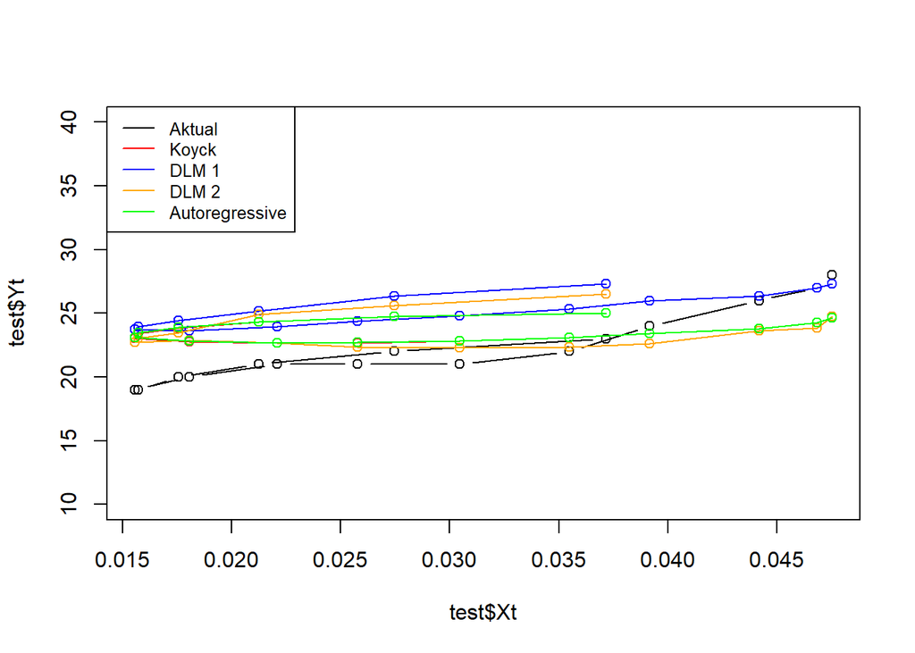

```r
par(mfrow=c(1,1))

plot(test$Xt, test$Yt, type="b", col="black", ylim=c(10,40))

# tambahkan garis ramalan dari masing-masing model
points(test$Xt, fore.koyck$forecasts, col="red");   lines(test$Xt, fore.koyck$forecasts, col="red")
points(test$Xt, fore.dlm$forecasts, col="blue");    lines(test$Xt, fore.dlm$forecasts, col="blue")
points(test$Xt, fore.dlm2$forecasts, col="orange"); lines(test$Xt, fore.dlm2$forecasts, col="orange")
points(test$Xt, fore.ardl$forecasts, col="green");  lines(test$Xt, fore.ardl$forecasts, col="green")

# legenda model
legend("topleft",
       c("Aktual", "Koyck","DLM 1","DLM 2", "Autoregressive"),
       lty=1, col=c("black","red","blue","orange","green"), cex=0.8)
```